# CTCF detachment versus histone modifications and other changes

### 3. Plot in R

I can now use the output from deeptools in R to make prettier plots. Start doing that here.

Start by loading in the features.

```r
# Load the bed files
ctcf_lad <- import(ctcf_lad_bed)
#ctcf_ilad <- import(ctcf_ilad_bed)
genes_active_lad <- import(genes_active_lad_bed)
random <- import(random_lad_bed)
```

First, the histone modifications.

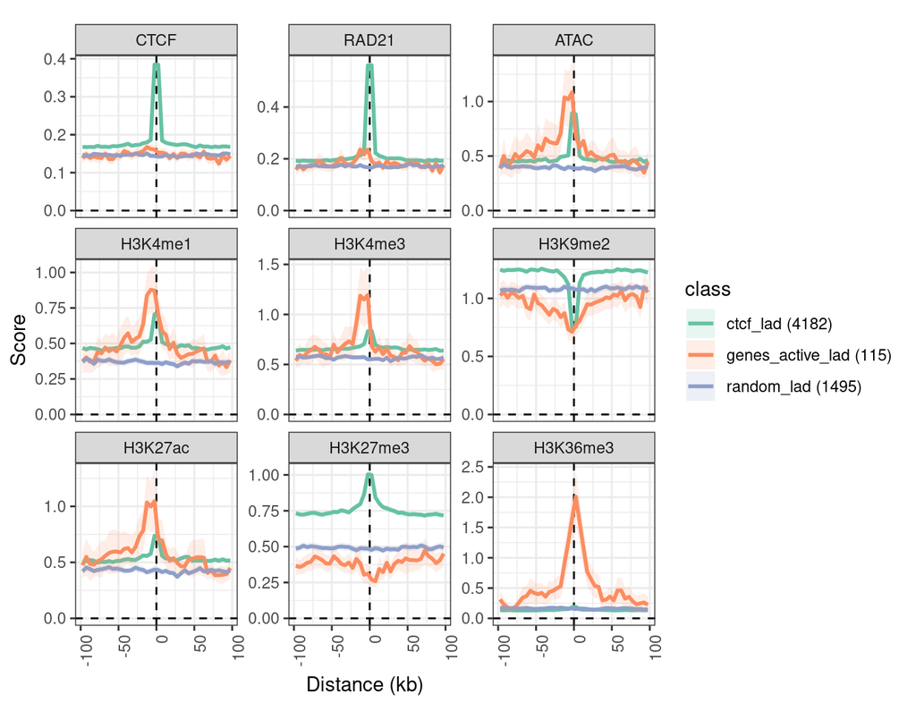

```r
# 1) Load data - histones

# Prepare experiment details
exp_name <- "CTCF_peaks"

# Load deeptools output
tib_data <- read_tsv(file.path(deeptools_dir, paste0(exp_name,
                                                "-deeptoolsMatrix.gz")),
                skip = 1, col_names = F)

tib_meta <- tib_data[, 1:6]
tib_values <- tib_data[, 7:ncol(tib_data)]

# Update metadata
tib_meta <- tib_meta %>%
  rename_all(~ c("seqnames", "start", "end", "name", "score", "strand")) %>%
  mutate(class = rep(c("ctcf_lad", "genes_active_lad", "random_lad"),
                     times = c(length(ctcf_lad),
                               length(genes_active_lad),
                               length(random))))

tib_values_gather <- tib_values %>%
  add_column(class = tib_meta$class) %>%
  rename_at(1:(ncol(.)-1),
            ~ paste(rep(track_names_histones, each = 40), 1:40, sep = "_")) %>%
  mutate(feature = 1:nrow(.)) %>%
  gather(key, value, -class, -feature) %>%
  mutate(track = str_remove(key, "_[0-9]+$"),
         track = factor(track, track_names_histones),
         bin = str_remove(key, ".*_"),
         bin = as.numeric(bin),
         distance = -extend - bin_size/2 + bin_size * bin,
         distance = distance / 1e3) %>%
  filter(! grepl("LaminB1", track)) %>%
  mutate(value = as.numeric(value))


# Add numbers to class names
tbl <- table(tib_meta$class)
idx <- match(tib_values_gather$class, names(tbl))
tib_values_gather <- tib_values_gather %>%
  mutate(class = paste0(class, " (", tbl[idx], ")"))


# Remove crazy values to prevent crazy things
tib_values_gather <- tib_values_gather %>%
  drop_na() %>%
  group_by(track) %>%
  mutate(limit1 = quantile(value, 0.001, na.rm = T),
         limit2 = quantile(value, 0.999, na.rm = T)) %>%
  ungroup() %>%
  rowwise() %>%
  mutate(value = replace(value, value < limit1, limit1),
         value = replace(value, value > limit2, limit2)) %>%
  dplyr::select(-limit1, -limit2) %>%
  ungroup()


# Plot
plt_base <- tib_values_gather %>%
  drop_na() %>%
  ggplot() +
  geom_vline(xintercept = 0, linetype = "dashed", col = "black") +
  geom_hline(yintercept = 0, linetype = "dashed", col = "black") +
  scale_color_brewer(palette = "Set2") +
  scale_fill_brewer(palette = "Set2") +
  xlab("Distance (kb)") +
  ylab("Score") +
  theme_bw() +
  theme(aspect.ratio = 1,
        axis.text.x = element_text(angle = 90, hjust = 1))

plt <- plt_base +
  stat_summary(fun = mean, geom = "line", size = 1,
               aes(x = distance, y = value, col = class)) +
  stat_summary(fun.data = mean_se, geom = "ribbon", alpha = 0.15, col = NA,
               aes(x = distance, y = value,
                   group = class, fill = class),
               fun.args = list(mult = 1.96)) +
  facet_wrap( ~ track, scales = "free_y")
plot(plt)
```

Next, the ATAC-seq data that we generated ourselves.

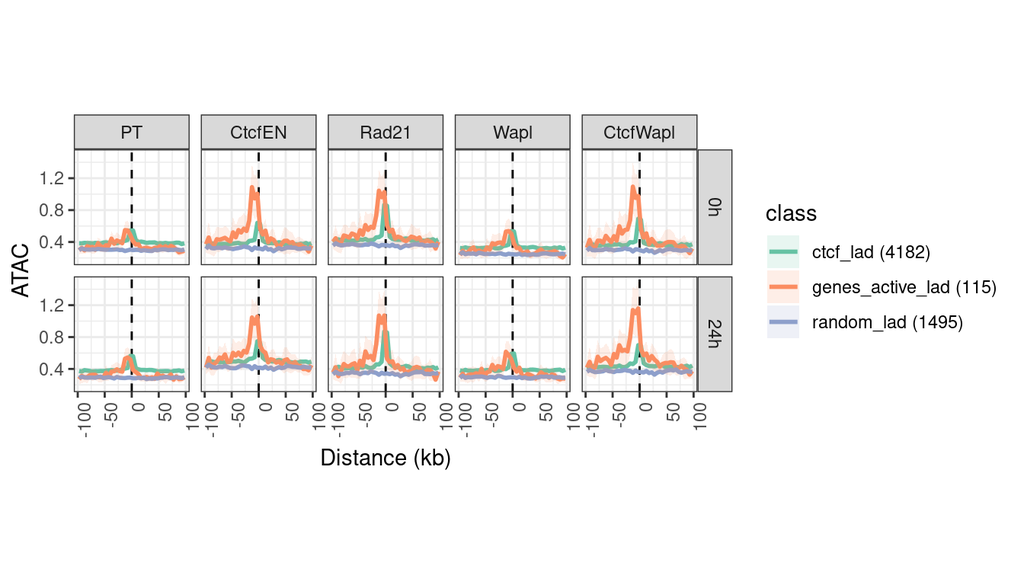

```r
# 1) Load data - first ATAC
# Prepare experiment details
exp_name <- "ATAC"

# Load deeptools output
tib_data <- read_tsv(file.path(deeptools_dir, paste0(exp_name,
                                                "-deeptoolsMatrix.gz")),
                skip = 1, col_names = F)

tib_meta <- tib_data[, 1:6]
tib_values <- tib_data[, 7:ncol(tib_data)]

# Update metadata
# tib_meta <- tib_meta %>%
#   rename_all(~ c("seqnames", "start", "end", "name", "score", "strand")) %>%
#   mutate(class = rep(c("ctcf_lad", "ctcf_ilad", "random_lad"),
#                      times = c(length(ctcf_lad),
#                                length(ctcf_ilad),
#                                length(random))))
tib_meta <- tib_meta %>%
  rename_all(~ c("seqnames", "start", "end", "name", "score", "strand")) %>%
  mutate(class = rep(c("ctcf_lad", "genes_active_lad", "random_lad"),
                     times = c(length(ctcf_lad),
                               length(genes_active_lad),
                               length(random))))

tib_values_gather <- tib_values %>%
    add_column(class = tib_meta$class) %>%
    rename_at(1:(ncol(.)-1),
              ~ paste(rep(track_names_atac, each = 40), 1:40, sep = "_")) %>%
    gather(key, value, -class) %>%
    mutate(experiment = str_remove(key, "_.*"),
           condition = str_remove(experiment, "0h|24h"),
           timepoint = ifelse(grepl("24h", experiment), "24h", "0h"),
           bin = str_remove(key, ".*_"),
           condition = factor(condition,
                              levels = c("PT", "CtcfEN", "Rad21",
                                         "Wapl", "CtcfWapl")),
           timepoint = factor(timepoint,
                              levels = c("0h", "24h")),
           bin = as.numeric(bin),
           distance = -extend - bin_size/2 + bin_size * bin,
           distance = distance / 1e3) %>%
  mutate(value = as.numeric(value))

# Add numbers to class names
tbl <- table(tib_meta$class)
idx <- match(tib_values_gather$class, names(tbl))
tib_values_gather <- tib_values_gather %>%
  mutate(class = paste0(class, " (", tbl[idx], ")"))


# Remove crazy values to prevent crazy things
tib_values_gather <- tib_values_gather %>%
  drop_na() %>%
  group_by(condition) %>%
  mutate(limit1 = quantile(value, 0.001, na.rm = T),
         limit2 = quantile(value, 0.999, na.rm = T)) %>%
  ungroup() %>%
  rowwise() %>%
  mutate(value = replace(value, value < limit1, limit1),
         value = replace(value, value > limit2, limit2)) %>%
  dplyr::select(-limit1, -limit2) %>%
  ungroup()

# Plot
plt_base <- tib_values_gather %>%
  drop_na() %>%
  ggplot() +
  geom_vline(xintercept = 0, linetype = "dashed", col = "black") +
  scale_color_brewer(palette = "Set2") +
  scale_fill_brewer(palette = "Set2") +
  xlab("Distance (kb)") +
  ylab("ATAC") +
  theme_bw() +
  theme(aspect.ratio = 1,
        axis.text.x = element_text(angle = 90, hjust = 1))

plt <- plt_base +
  stat_summary(fun = mean, geom = "line", size = 1,
               aes(x = distance, y = value, col = class)) +
  stat_summary(fun.data = mean_se, geom = "ribbon", alpha = 0.15, col = NA,
               aes(x = distance, y = value,
                   group = class, fill = class),
               fun.args = list(mult = 1.96)) +
  facet_grid(timepoint ~ condition)
plot(plt)
```

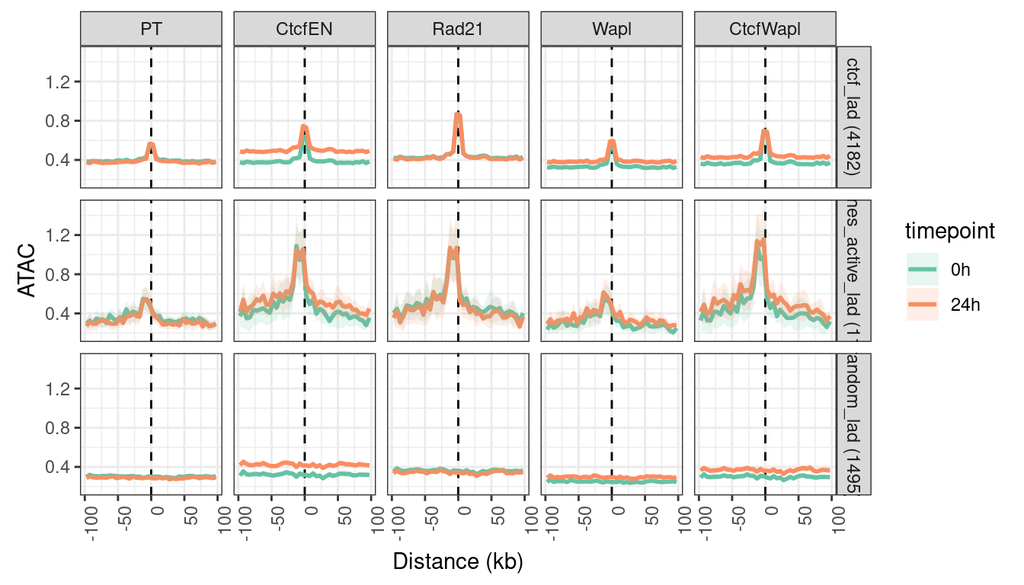

```r
plt <- plt_base +
  #geom_line(aes(x = location, y = value, col = timepoint)) +
  stat_summary(fun = mean, geom = "line", size = 1,
               aes(x = distance, y = value, col = timepoint)) +
  stat_summary(fun.data = mean_se, geom = "ribbon", alpha = 0.15, col = NA,
               aes(x = distance, y = value,
                   group = timepoint, fill = timepoint),
               fun.args = list(mult = 1.96)) +
  facet_grid(class ~ condition)
plot(plt)
```

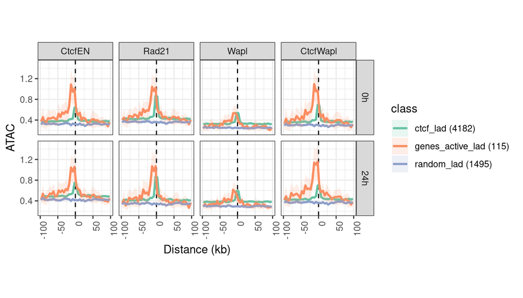

```r
# Without PT
plt_base <- tib_values_gather %>%
  filter(condition != "PT") %>%
  drop_na() %>%
  ggplot() +
  geom_vline(xintercept = 0, linetype = "dashed", col = "black") +
  scale_color_brewer(palette = "Set2") +
  scale_fill_brewer(palette = "Set2") +
  xlab("Distance (kb)") +
  ylab("ATAC") +
  theme_bw() +
  theme(aspect.ratio = 1,
        axis.text.x = element_text(angle = 90, hjust = 1))

plt <- plt_base +
  stat_summary(fun = mean, geom = "line", size = 1,
               aes(x = distance, y = value, col = class)) +
  stat_summary(fun.data = mean_se, geom = "ribbon", alpha = 0.15, col = NA,
               aes(x = distance, y = value,
                   group = class, fill = class),
               fun.args = list(mult = 1.96)) +
  facet_grid(timepoint ~ condition)
plot(plt)
```

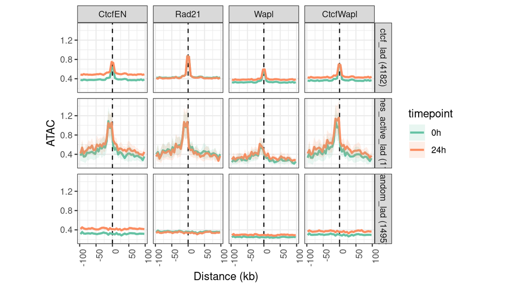

```r
plt <- plt_base +
  #geom_line(aes(x = location, y = value, col = timepoint)) +
  stat_summary(fun = mean, geom = "line", size = 1,
               aes(x = distance, y = value, col = timepoint)) +
  stat_summary(fun.data = mean_se, geom = "ribbon", alpha = 0.15, col = NA,
               aes(x = distance, y = value,
                   group = timepoint, fill = timepoint),
               fun.args = list(mult = 1.96)) +
  facet_grid(class ~ condition)
plot(plt)
```

Next, make some plots of gene expression.

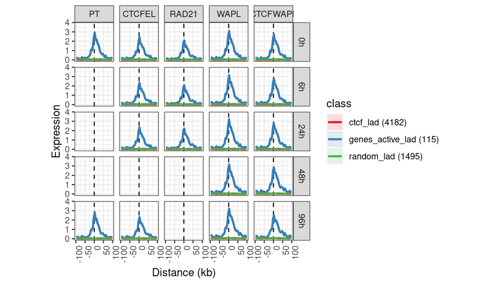

```r
# Load data - expression
exp_name <- "gene_expression"

# Load deeptools output
tib_data <- read_tsv(file.path(deeptools_dir, paste0(exp_name,
                                                "-deeptoolsMatrix.gz")),
                skip = 1, col_names = F)

tib_meta <- tib_data[, 1:6]
tib_values <- tib_data[, 7:ncol(tib_data)]

# Update metadata
# tib_meta <- tib_meta %>%
#   rename_all(~ c("seqnames", "start", "end", "name", "score", "strand")) %>%
#   mutate(class = rep(c("ctcf_lad", "ctcf_ilad", "random_lad"),
#                      times = c(length(ctcf_lad),
#                                length(ctcf_ilad),
#                                length(random))))
tib_meta <- tib_meta %>%
  rename_all(~ c("seqnames", "start", "end", "name", "score", "strand")) %>%
  mutate(class = rep(c("ctcf_lad", "genes_active_lad", "random_lad"),
                     times = c(length(ctcf_lad),
                               length(genes_active_lad),
                               length(random))))

tib_values_gather <- tib_values %>%
  add_column(class = tib_meta$class) %>%
  rename_at(1:(ncol(.)-1),
            ~ paste(rep(track_names_expression, each = 40),
                    1:40, sep = "_")) %>%
  gather(key, value, -class) %>%
  # Select only CTCFEL
  filter(! grepl("NQL", key)) %>%
  mutate(key = str_replace(key, "CTCF_EN", "CTCFEL")) %>%
  separate(key, c("condition", "timepoint", "replicate", "bin"),
           remove = F) %>%
  mutate(condition = factor(condition,
                            levels = c("PT", "CTCFEL", "RAD21",
                                       "WAPL", "CTCFWAPL")),
         timepoint = factor(timepoint,
                            levels = c("0h", "6h", "24h", "48h", "96h")),
         bin = as.numeric(bin),
         distance = -extend - bin_size/2 + bin_size * bin,
         distance = distance / 1e3) %>%
  mutate(value = as.numeric(value))

# Add numbers to class names
tbl <- table(tib_meta$class)
idx <- match(tib_values_gather$class, names(tbl))
tib_values_gather <- tib_values_gather %>%
  mutate(class = paste0(class, " (", tbl[idx], ")"))


# Remove crazy values to prevent crazy things
tib_values_gather <- tib_values_gather %>%
  drop_na() %>%
  group_by(condition) %>%
  mutate(limit1 = quantile(value, 0.001, na.rm = T),
         limit2 = quantile(value, 0.999, na.rm = T)) %>%
  ungroup() %>%
  rowwise() %>%
  mutate(value = replace(value, value < limit1, limit1),
         value = replace(value, value > limit2, limit2)) %>%
  dplyr::select(-limit1, -limit2) %>%
  ungroup()

# Plot
plt_base <- tib_values_gather %>%
  drop_na() %>%
  ggplot() +
  geom_vline(xintercept = 0, linetype = "dashed", col = "black") +
  scale_color_brewer(palette = "Set1") +
  scale_fill_brewer(palette = "Set1") +
  xlab("Distance (kb)") +
  ylab("Expression") +
  theme_bw() +
  theme(aspect.ratio = 1,
        axis.text.x = element_text(angle = 90, hjust = 1))

plt <- plt_base +
  stat_summary(fun = mean, geom = "line", size = 1,
               aes(x = distance, y = value, col = class)) +
  stat_summary(fun.data = mean_se, geom = "ribbon", alpha = 0.15, col = NA,
               aes(x = distance, y = value,
                   group = class, fill = class),
               fun.args = list(mult = 1.96)) +
  facet_grid(timepoint ~ condition)
plot(plt)
```

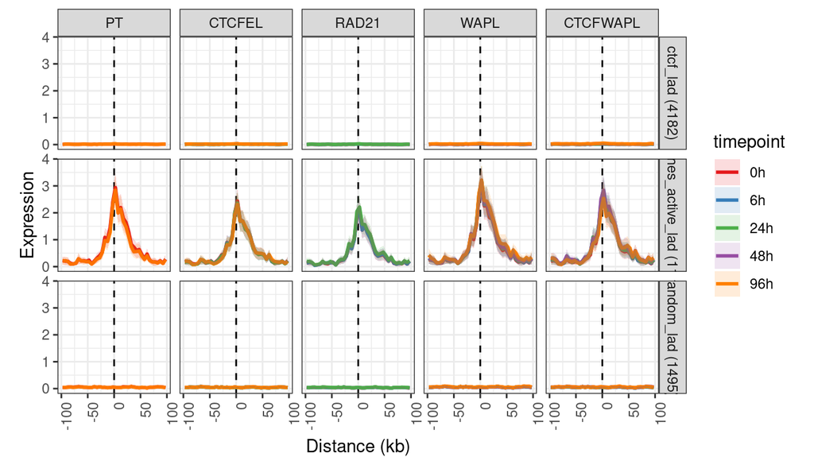

```r
plt <- plt_base +
  #geom_line(aes(x = location, y = value, col = timepoint)) +
  stat_summary(fun = mean, geom = "line", size = 1,
               aes(x = distance, y = value, col = timepoint)) +
  stat_summary(fun.data = mean_se, geom = "ribbon", alpha = 0.15, col = NA,
               aes(x = distance, y = value,
                   group = timepoint, fill = timepoint),
               fun.args = list(mult = 1.96)) +
  facet_grid(class ~ condition)
plot(plt)
```

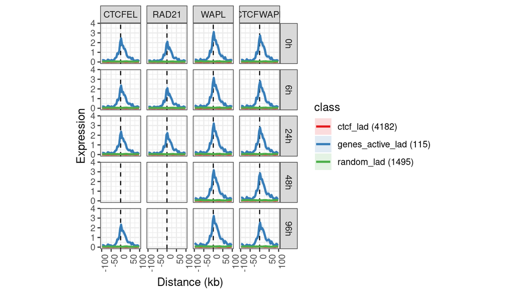

```r
# Without PT
plt_base <- tib_values_gather %>%
  filter(condition != "PT") %>%
  drop_na() %>%
  ggplot() +
  geom_vline(xintercept = 0, linetype = "dashed", col = "black") +
  scale_color_brewer(palette = "Set1") +
  scale_fill_brewer(palette = "Set1") +
  xlab("Distance (kb)") +
  ylab("Expression") +
  theme_bw() +
  theme(aspect.ratio = 1,
        axis.text.x = element_text(angle = 90, hjust = 1))

plt <- plt_base +
  stat_summary(fun = mean, geom = "line", size = 1,
               aes(x = distance, y = value, col = class)) +
  stat_summary(fun.data = mean_se, geom = "ribbon", alpha = 0.15, col = NA,
               aes(x = distance, y = value,
                   group = class, fill = class),
               fun.args = list(mult = 1.96)) +
  facet_grid(timepoint ~ condition)
plot(plt)
```

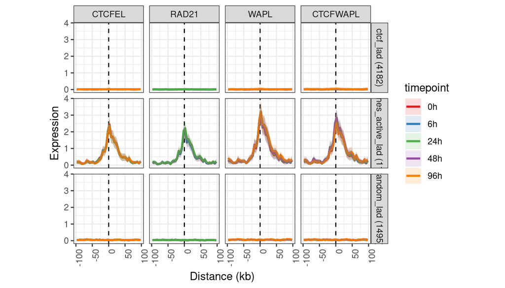

```r
plt <- plt_base +
  #geom_line(aes(x = location, y = value, col = timepoint)) +
  stat_summary(fun = mean, geom = "line", size = 1,
               aes(x = distance, y = value, col = timepoint)) +
  stat_summary(fun.data = mean_se, geom = "ribbon", alpha = 0.15, col = NA,
               aes(x = distance, y = value,
                   group = timepoint, fill = timepoint),
               fun.args = list(mult = 1.96)) +
  facet_grid(class ~ condition)
plot(plt)
```

Clearly, CTCF sites within LADs are not expressed.

Finally, show plots of H3K27me3 chip-seq

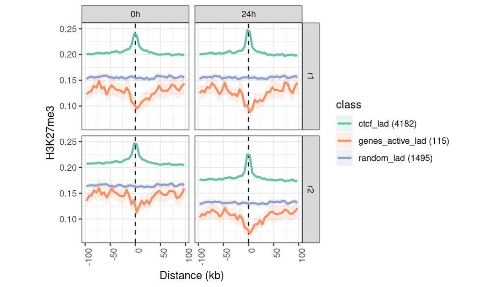

```r
# 1) Load data
# Prepare experiment details
exp_name <- "H3K27me3_chipseq"

# Load deeptools output
tib_data <- read_tsv(file.path(deeptools_dir, paste0(exp_name,
                                                "-deeptoolsMatrix.gz")),
                skip = 1, col_names = F)

tib_meta <- tib_data[, 1:6]
tib_values <- tib_data[, 7:ncol(tib_data)]

# Update metadata
# tib_meta <- tib_meta %>%
#   rename_all(~ c("seqnames", "start", "end", "name", "score", "strand")) %>%
#   mutate(class = rep(c("ctcf_lad", "ctcf_ilad", "random_lad"),
#                      times = c(length(ctcf_lad),
#                                length(ctcf_ilad),
#                                length(random))))
tib_meta <- tib_meta %>%
  rename_all(~ c("seqnames", "start", "end", "name", "score", "strand")) %>%
  mutate(class = rep(c("ctcf_lad", "genes_active_lad", "random_lad"),
                     times = c(length(ctcf_lad),
                               length(genes_active_lad),
                               length(random))))

tib_values_gather <- tib_values %>%
    add_column(class = tib_meta$class) %>%
    rename_at(1:(ncol(.)-1),
              ~ paste(rep(track_names_h3k27me3_chip, each = 40),
                      1:40, sep = "_")) %>%
    gather(key, value, -class) %>%
    mutate(track = str_remove(key, "_[0-9]+$"),
           timepoint = ifelse(grepl("24h", track), "24h", "0h"),
           replicate = ifelse(grepl("r1", track), "r1", "r2"),
           bin = str_remove(key, ".*_"),
           timepoint = factor(timepoint,
                              levels = c("0h", "24h")),
           bin = as.numeric(bin),
           distance = -extend - bin_size/2 + bin_size * bin,
           distance = distance / 1e3) %>%
  mutate(value = as.numeric(value))

# Add numbers to class names
tbl <- table(tib_meta$class)
idx <- match(tib_values_gather$class, names(tbl))
tib_values_gather <- tib_values_gather %>%
  mutate(class = paste0(class, " (", tbl[idx], ")"))


# Remove crazy values to prevent crazy things
tib_values_gather <- tib_values_gather %>%
  drop_na() %>%
  group_by(track) %>%
  mutate(limit1 = quantile(value, 0.001, na.rm = T),
         limit2 = quantile(value, 0.999, na.rm = T)) %>%
  ungroup() %>%
  rowwise() %>%
  mutate(value = replace(value, value < limit1, limit1),
         value = replace(value, value > limit2, limit2)) %>%
  dplyr::select(-limit1, -limit2) %>%
  ungroup()

# Remove LMNB1 and other base tracks
tib_values_gather <- tib_values_gather %>%
  filter(grepl("AID", track))

# Plot
plt_base <- tib_values_gather %>%
  drop_na() %>%
  ggplot() +
  geom_vline(xintercept = 0, linetype = "dashed", col = "black") +
  scale_color_brewer(palette = "Set2") +
  scale_fill_brewer(palette = "Set2") +
  xlab("Distance (kb)") +
  ylab("H3K27me3") +
  theme_bw() +
  theme(aspect.ratio = 1,
        axis.text.x = element_text(angle = 90, hjust = 1))

# With replicates
plt <- plt_base +
  stat_summary(fun = mean, geom = "line", size = 1,
               aes(x = distance, y = value, col = class)) +
  stat_summary(fun.data = mean_se, geom = "ribbon", alpha = 0.15, col = NA,
               aes(x = distance, y = value,
                   group = class, fill = class),
               fun.args = list(mult = 1.96)) +
  facet_grid(replicate ~ timepoint)
plot(plt)
```

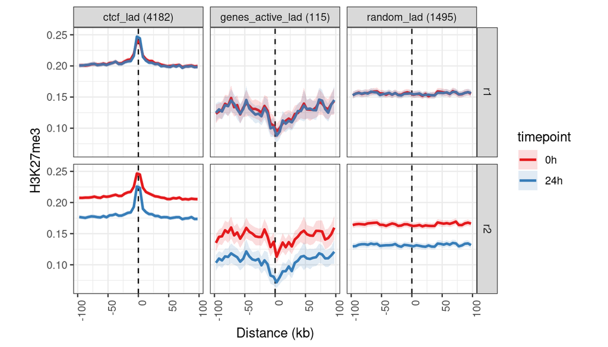

```r
plt <- plt_base +
  #geom_line(aes(x = location, y = value, col = timepoint)) +
  stat_summary(fun = mean, geom = "line", size = 1,
               aes(x = distance, y = value, col = timepoint)) +
  stat_summary(fun.data = mean_se, geom = "ribbon", alpha = 0.15, col = NA,
               aes(x = distance, y = value,
                   group = timepoint, fill = timepoint),
               fun.args = list(mult = 1.96)) +
  scale_color_brewer(palette = "Set1") +
  scale_fill_brewer(palette = "Set1") +
  facet_grid(replicate ~ class)
plot(plt)
```

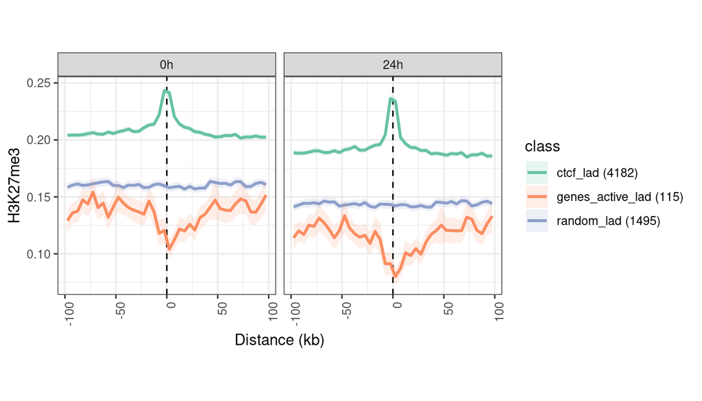

```r
# Without replicates
plt <- plt_base +
  stat_summary(fun = mean, geom = "line", size = 1,
               aes(x = distance, y = value, col = class)) +
  stat_summary(fun.data = mean_se, geom = "ribbon", alpha = 0.15, col = NA,
               aes(x = distance, y = value,
                   group = class, fill = class),
               fun.args = list(mult = 1.96)) +
  facet_grid(. ~ timepoint)
plot(plt)
```

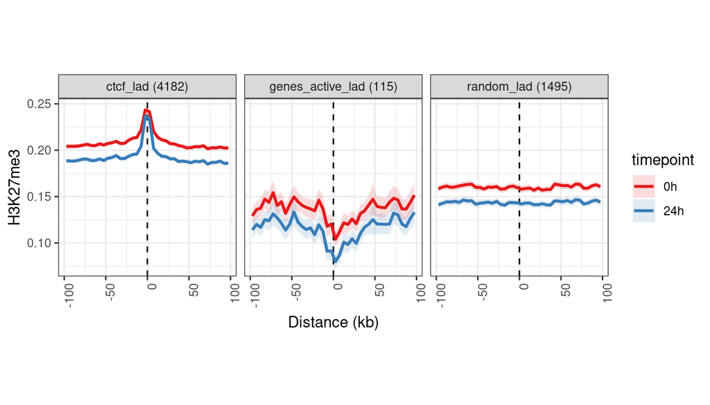

```r
plt <- plt_base +
  #geom_line(aes(x = location, y = value, col = timepoint)) +
  stat_summary(fun = mean, geom = "line", size = 1,
               aes(x = distance, y = value, col = timepoint)) +
  stat_summary(fun.data = mean_se, geom = "ribbon", alpha = 0.15, col = NA,
               aes(x = distance, y = value,
                   group = timepoint, fill = timepoint),
               fun.args = list(mult = 1.96)) +
  scale_color_brewer(palette = "Set1") +
  scale_fill_brewer(palette = "Set1") +
  facet_grid(. ~ class)
plot(plt)
```

### Conclusion

Looks good.

- CTCF sites are correlated with various epigenetic features, including an enrichment of H3K27me3 and some active features. Also ATAC-seq. And a depletion for H3K9me2. No transcription as estimated with H3K36me3 signal. (And gene expression.)
- ATAC-seq signal is not affected by a loss of LaminB1 detachment at CTCF sites.